# R4DS_2E_dataVisualization

```r
# Now we see there is a decently positive correlation between bill_length and bill_depth among the three different
# species
```

4. What happens if you make a scatterplot of species vs. bill_depth_mm? What might be a better choice of geom?

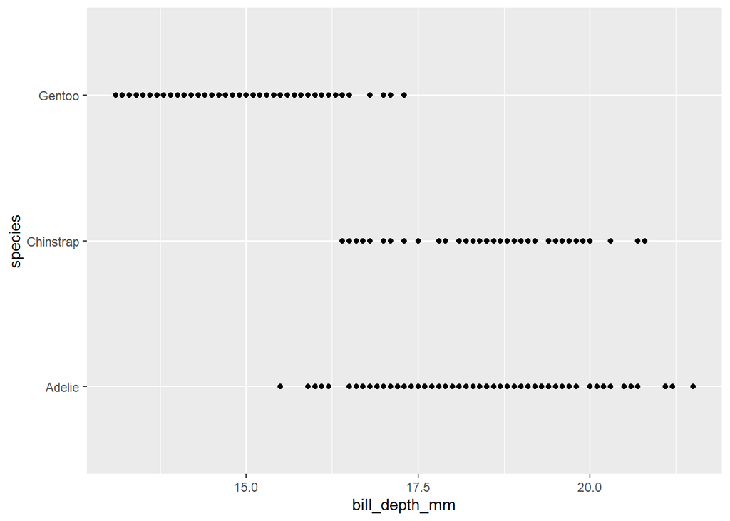

```r
ggplot(data = penguins,
       mapping = aes(x = bill_depth_mm, y = species)
) +
  geom_point()
```

```r
# This isn't that good of a visualization since we have a categorical variable (Species)
# I think a better geom might be something like a boxplot so we can see the spread of bill_depth_mm between each
# species, mean etc.
```

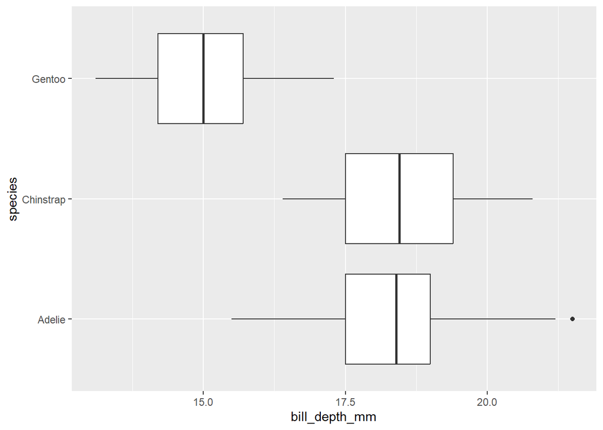

```r
ggplot(data = penguins,
       mapping = aes(x = bill_depth_mm, y = species)
) +
  geom_boxplot()
```

```r
# We get more information out of this. Minimum, maximum, Lower quartile, upper quartile and the median etc. of each species
```

5. Why does the following give an error and how would you fix it?

ggplot(data = penguins) + geom_point()

```r
ggplot(data = penguins) +
  geom_point()
```

```
## Error in `geom_point()`:
## ! Problem while setting up geom.
## ℹ Error occurred in the 1st layer.
## Caused by error in `compute_geom_1()`:
## ! `geom_point()` requires the following missing aesthetics: x and y.
```

```
## Warning: Removed 2 rows containing missing values or values outside the scale range
## (`geom_point()`).
```

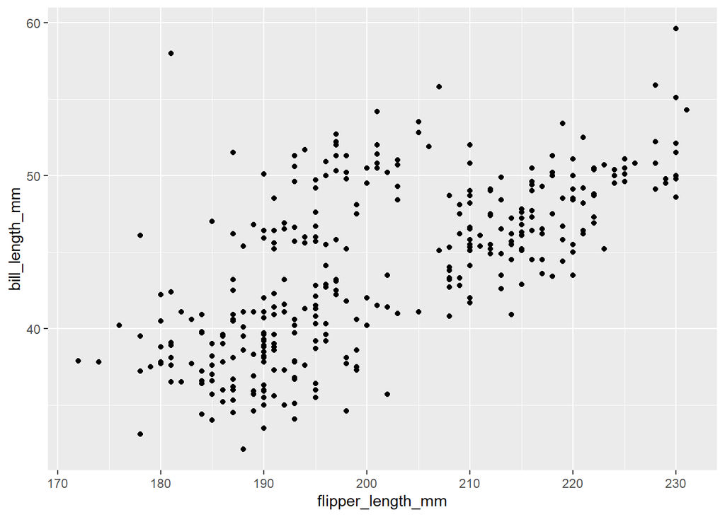

```r
# We get the following error message:
# Caused by error in `compute_geom_1()`:
# ! `geom_point()` requires the following missing aesthetics: x and y
# So we can fix this by simply adding an aesthetics for the x & y axis. Maybe we can do the following:

ggplot(data = penguins,
       mapping = aes(x = flipper_length_mm, y = bill_length_mm)) +
  geom_point()
```

6. What does the na.rm argument do in geom_point()? What is the default value of the argument? Create a scatterplot where you successfully use this argument set to TRUE.

na.rm argument removes any missing values or NA values when plotting each observation. The default value is set to FALSE and we get a warning saying we have certain missing values for some observations.

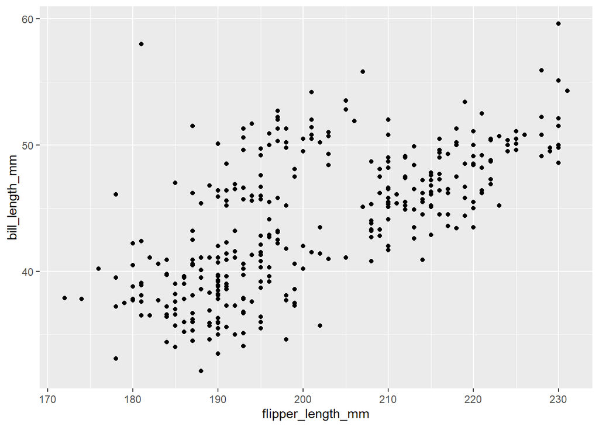

```r
ggplot(data = penguins,
       mapping = aes(x = flipper_length_mm, y = bill_length_mm)) +
  geom_point(na.rm = TRUE)
```

7. Add the following caption to the plot you made in the previous exercise: “Data come from the palmerpenguins package.” Hint: Take a look at the documentation for labs().

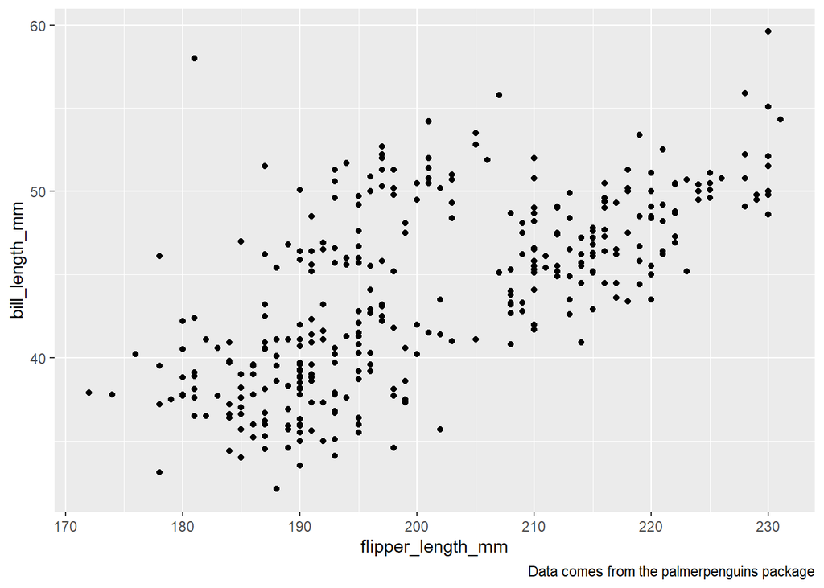

```r
ggplot(data = penguins,
       mapping = aes(x = flipper_length_mm, y = bill_length_mm)) +
  geom_point(na.rm = TRUE) +
  labs(caption = "Data comes from the palmerpenguins package")
```

8. Recreate the following visualization. What aesthetic should bill_depth_mm be mapped to? And should it be mapped at the global level or at the geom level?

It looks like bill_depth_mm should be mapped to geom_point and not the global mapping within the ggplot function since there is a single smooth line through every possible bill_depth_mm value.

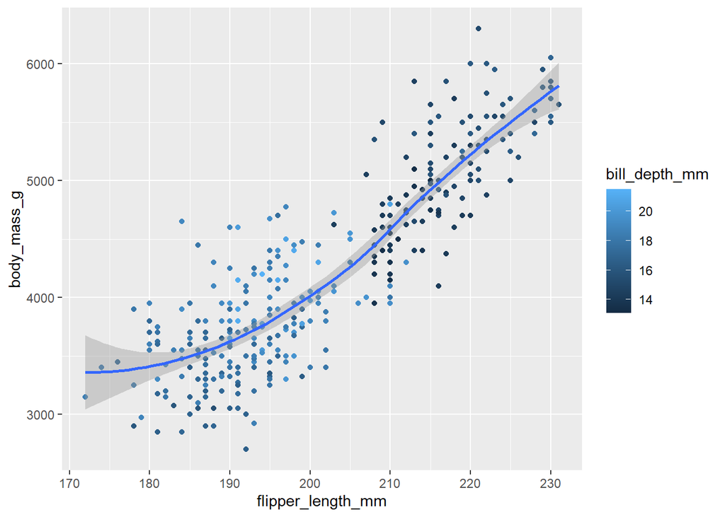

```r
ggplot(data = penguins,
       mapping = aes(x = flipper_length_mm, y = body_mass_g)) +
  geom_point(aes(color = bill_depth_mm)) +
  geom_smooth()
```

9. Run this code in your head and predict what the output will look like. Then, run the code in R and check your predictions.

ggplot( data = penguins, mapping = aes(x = flipper_length_mm, y = body_mass_g, color = island) ) + geom_point() + geom_smooth(se = FALSE)

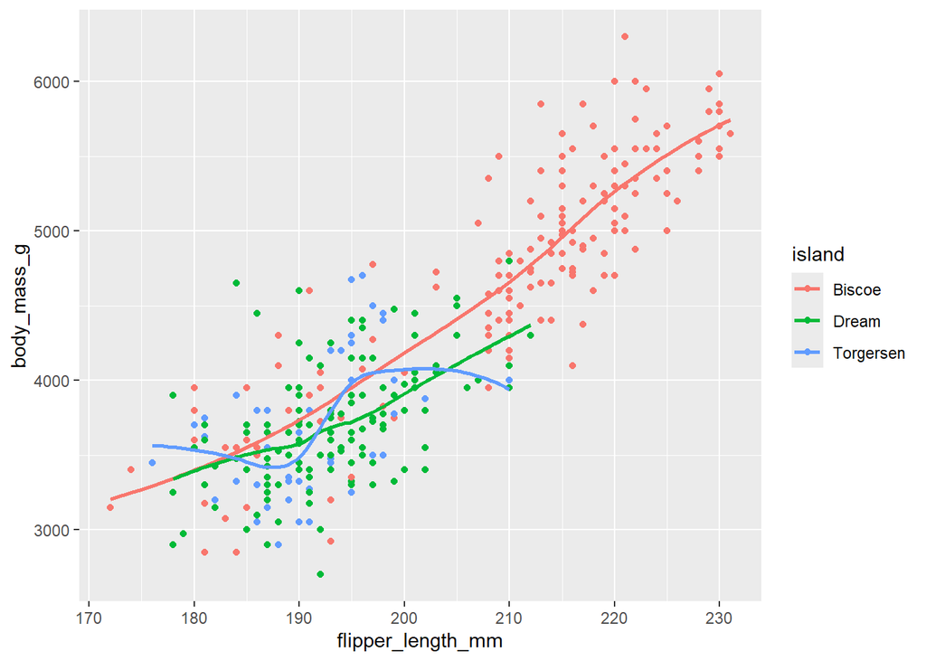

```r
# It will map flipper_length_mm vs body_mass_g and separate them by colour according to the island the penguin resides. Since the colour argument is given in the global mapping, we will see a regression line for each possible island. Also `se = FALSE` so there won't be a confidence interval around each regression line.

ggplot(
  data = penguins,
  mapping = aes(x = flipper_length_mm, y = body_mass_g, color = island)
) +
  geom_point() +
  geom_smooth(se = FALSE)
```

10. Will these two graphs look different? Why/why not?

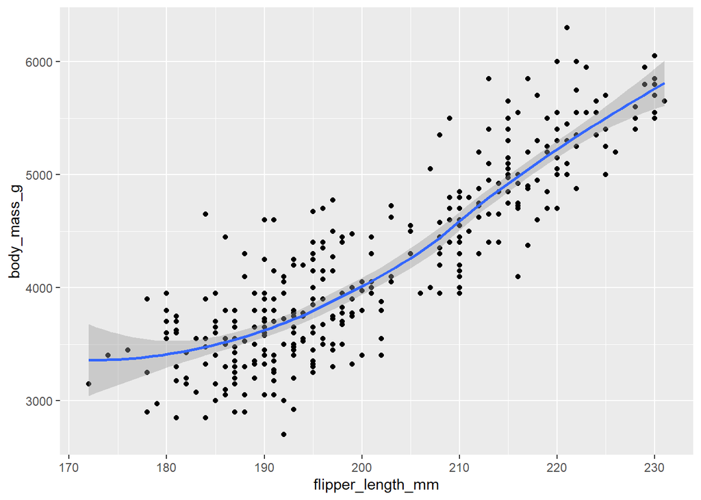

```r
ggplot(
  data = penguins,
  mapping = aes(x = flipper_length_mm, y = body_mass_g)
) +
  geom_point() +
  geom_smooth()
```

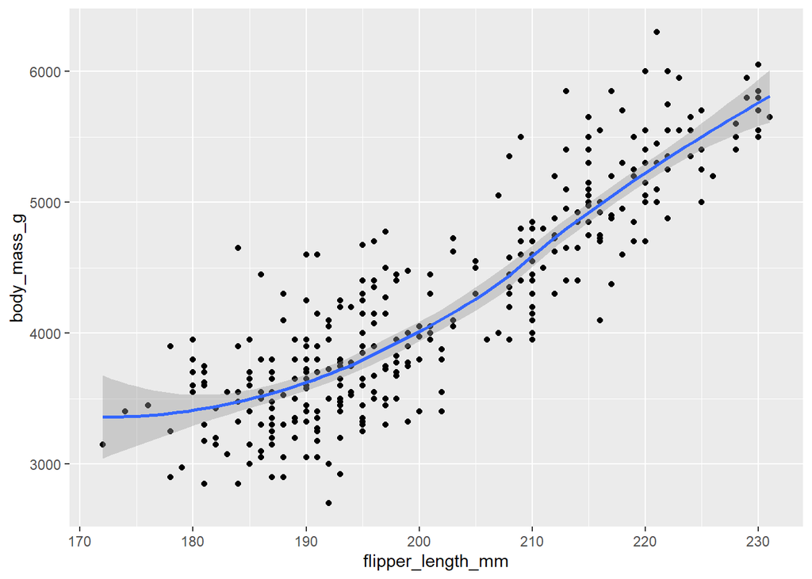

```r
# The above code makes a scatterplot that maps body_mass_g vs flipper_length_mm of the penguins and also adds a regression line.

ggplot() +
  geom_point(
    data = penguins,
    mapping = aes(x = flipper_length_mm, y = body_mass_g)
  ) +
  geom_smooth(
    data = penguins,
    mapping = aes(x = flipper_length_mm, y = body_mass_g)
  )
```

```r
# This above code I believe will also make the exact same plot since even though we haven't got any global mapping being passed to each geom function, for each individual geom function however the mapping are identical
```

## Data Visualization Exercises - Visualizing distributions

1. Make a bar plot of species of penguins, where you assign species to the y aesthetic. How is this plot different?

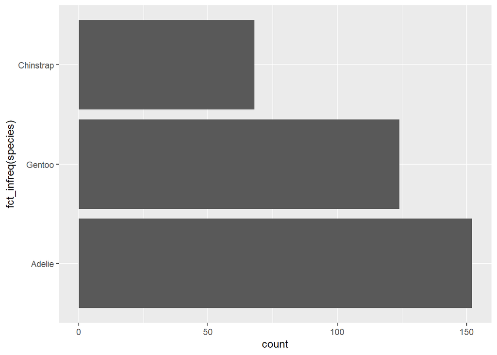

```r
ggplot(penguins, aes(y = fct_infreq(species))) +
  geom_bar()
```

```r
# This plot is different as its now horizontal. The count for each species is given in ascending order as seen by the smallest count on top (top to bottom)
```

2. How are the following two plots different? Which aesthetic, color or fill, is more useful for changing the color of bars?

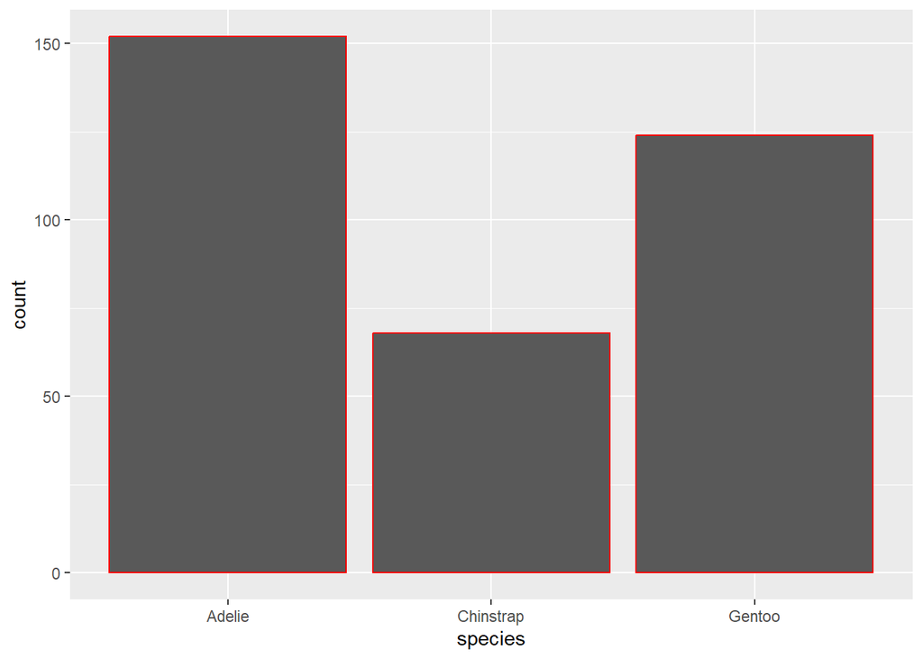

```r
ggplot(penguins, aes(x = species)) +
  geom_bar(color = "red")
```

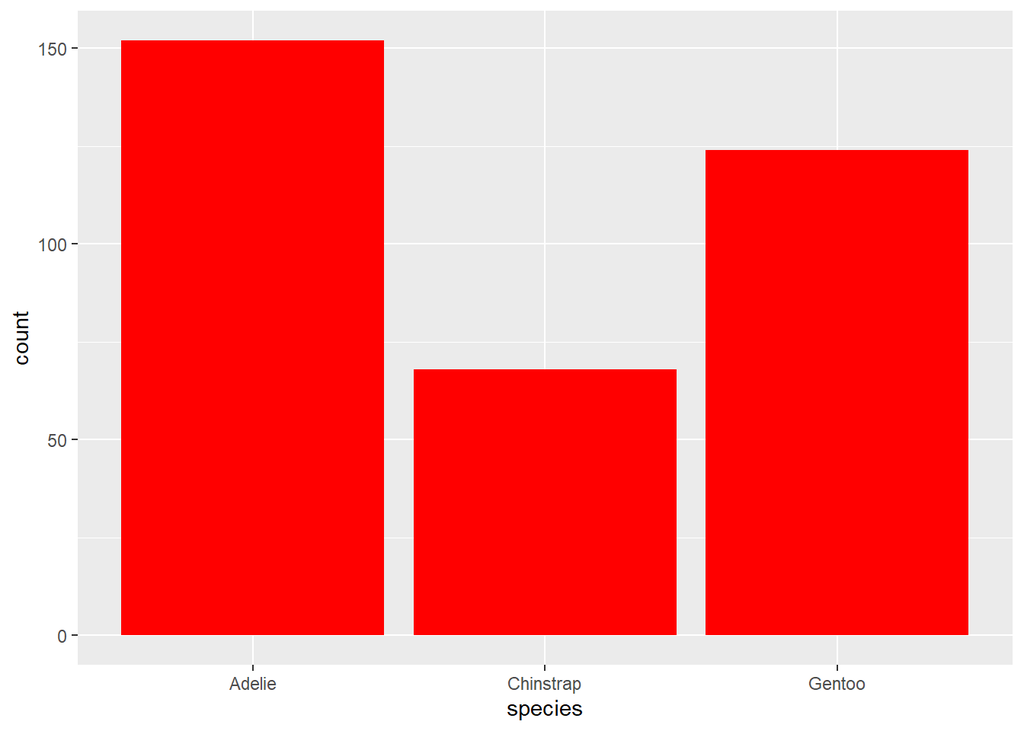

```r
# If you only use the color argument in `geom_bar` it adds a red line around each bar (Which isn't really the intended effect)

ggplot(penguins, aes(x = species)) +
  geom_bar(fill = "red")
```